# Statistical Graphics

# Themes

A great part of ggplot2 is the ability to use themes to easily change the way plots look. While building a theme from scratch can be daunting, Jeffrey Arnold from the University of Rochester has put together ggthemes, a package of themes to re-create commonly used styles of graphs. Just a few styles-The Economist, Excel, Edward Tufte and The Wall Street Journal-are exhibited in figure below:

```r
require(ggthemes)
```

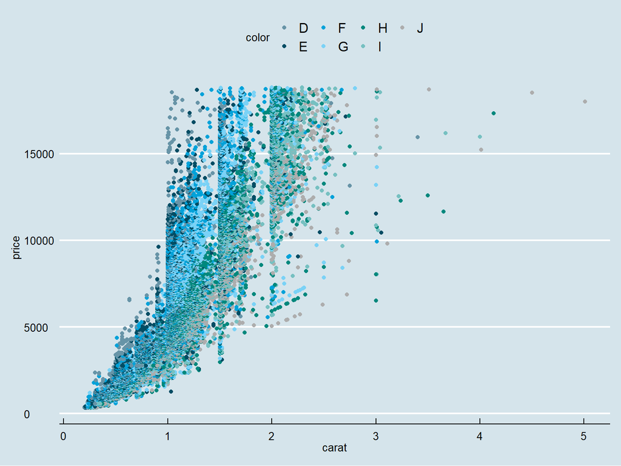

```r
# build a plot and store it in g2
g2 <- ggplot(diamonds, aes(x=carat, y=price)) + geom_point(aes(color=color))
# apply a few themes
g2 + theme_economist() + scale_colour_economist()
```

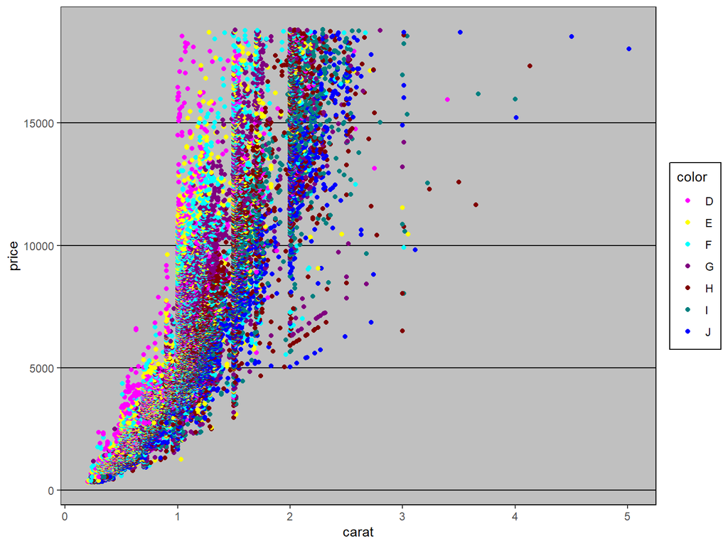

```r
g2 + theme_excel() + scale_colour_excel()
```

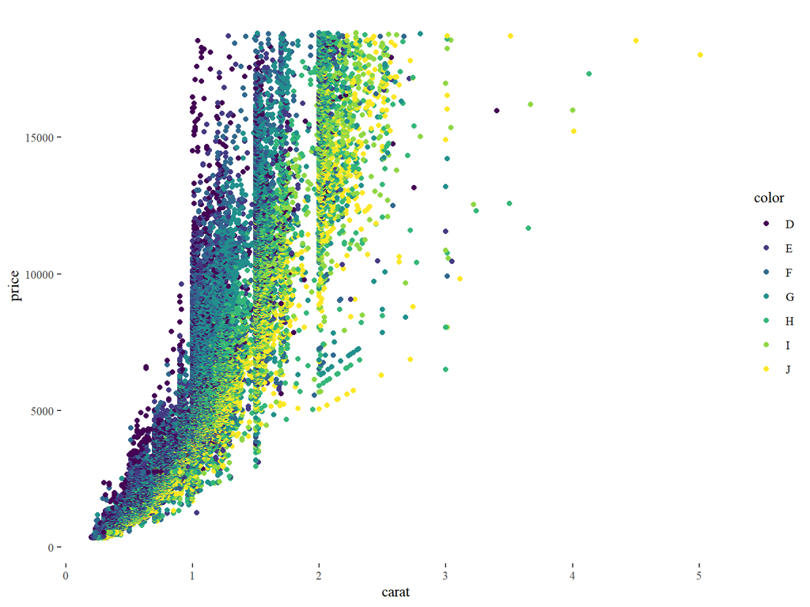

```r
g2 + theme_tufte()
```

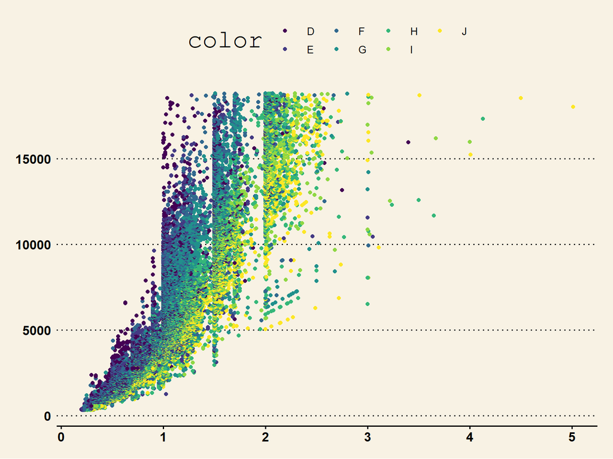

```r
g2 + theme_wsj()
```

# Conclusion

We have seen both basic graphs and ggplot graphs that are both nicer and easier to create. We have covered histograms, scatterplots, boxplots, line plots and density graphs. We have also looked at using colors and small multiples for distinguishing data. There are many other features in ggplot2 such as jittering, stacking, dodging and alpha, which we will demonstrate in context throughout the book.